Sena Gümüştekin 20200305013 Nilay Özcan 20200305027

# **| Dataset**

# **| Exploratory Data Analysis (EDA)**

## **1 | Import Essential Libraries**

`pandas` is a library that allows us to analyze and easily work with data in tabular form, `matplotlib.pyplot` visualizes data by plotting graphs, `seaborn` is built on top of `matplotlib` for creating more advanced visualizations, and `zscore` enables normalization based on standard deviation.

```python
import pandas as pd
import matplotlib.pyplot as plt
import seaborn as sns
from scipy.stats import zscore
```

## **2 | Import Dataset**

```python
df = pd.read_csv("20200305013.csv")
df.head(5)
```

|  | Age | Gender | BMI | SBP | DBP | FPG | Chol | Tri | HDL | LDL | ALT | BUN | CCR | FFPG | smoking | drinking | family_histroy | Diabetes |
| --- | --- | --- | --- | --- | --- | --- | --- | --- | --- | --- | --- | --- | --- | --- | --- | --- | --- | --- |
| 0 | 26 | 1 | 20.1 | 119 | 81 | 5.80 | 4.36 | 0.86 | 0.90 | 2.43 | 12.0 | 5.40 | 63.8 | 5.40 | 3.0 | 3.0 | 0 | 0 |
| 1 | 40 | 1 | 17.7 | 97 | 54 | 4.60 | 3.70 | 1.02 | 1.50 | 2.04 | 9.2 | 3.70 | 70.3 | 4.10 | 1.0 | 1.0 | 0 | 0 |
| 2 | 40 | 2 | 19.7 | 85 | 53 | 5.30 | 5.87 | 1.29 | 1.75 | 3.37 | 10.1 | 4.10 | 61.1 | 4.85 | 3.0 | 3.0 | 0 | 0 |
| 3 | 43 | 1 | 23.1 | 111 | 71 | 4.50 | 4.05 | 0.74 | 1.27 | 2.60 | 36.5 | 4.38 | 73.4 | 5.30 | 2.0 | 3.0 | 0 | 0 |
| 4 | 36 | 1 | 26.5 | 130 | 82 | 5.54 | 6.69 | 3.49 | 0.91 | 3.64 | 69.3 | 3.86 | 67.5 | 5.53 | 3.0 | 3.0 | 0 | 0 |

## **3 | Identify the Types of Variables**

The df.info function provides general information about the data, including the total number of rows, number of columns, column names, the number of non-null values in each column, and data types.

```python
df.info()
```

```
<class 'pandas.core.frame.DataFrame'>
RangeIndex: 4303 entries, 0 to 4302
Data columns (total 18 columns):
 #   Column          Non-Null Count  Dtype
---  ------          --------------  -----
 0   Age             4303 non-null   int64
 1   Gender          4303 non-null   int64
 2   BMI             4303 non-null   float64
 3   SBP             4303 non-null   int64
 4   DBP             4303 non-null   int64
 5   FPG             4303 non-null   float64
 6   Chol            4303 non-null   float64
 7   Tri             4303 non-null   float64
 8   HDL             4303 non-null   float64
 9   LDL             4303 non-null   float64
 10  ALT             4303 non-null   float64
 11  BUN             4303 non-null   float64
 12  CCR             4303 non-null   float64
 13  FFPG            4303 non-null   float64
 14  smoking         4303 non-null   float64
 15  drinking        4303 non-null   float64
 16  family_histroy  4303 non-null   int64
 17  Diabetes        4303 non-null   int64
dtypes: float64(12), int64(6)
memory usage: 605.2 KB
```

## **4 | Summary Statistics**

The `df.describe()` command provides summary statistics for numerical columns. These statistics include the count, mean, standard deviation (std), minimum and maximum values, and quartiles (25%, 50%, 75%). This command is used to quickly gain insights into the distribution of numerical columns in the dataset.

```python
df.describe()
```

|  | Age | Gender | BMI | SBP | DBP | FPG | Chol | Tri | HDL | LDL | ALT | BUN | CCR | FFPG | smoking | drinking | family_histroy | Diabetes |
| --- | --- | --- | --- | --- | --- | --- | --- | --- | --- | --- | --- | --- | --- | --- | --- | --- | --- | --- |
| count | 4303.000000 | 4303.000000 | 4303.000000 | 4303.000000 | 4303.000000 | 4303.000000 | 4303.000000 | 4303.000000 | 4303.000000 | 4303.000000 | 4303.000000 | 4303.000000 | 4303.000000 | 4303.000000 | 4303.000000 | 4303.000000 | 4303.000000 | 4303.000000 |
| mean | 48.085057 | 1.351615 | 24.123923 | 123.219382 | 76.360446 | 5.226368 | 4.860753 | 1.588476 | 1.666765 | 2.976220 | 26.754810 | 4.841088 | 71.557080 | 5.729084 | 3.006123 | 3.209935 | 0.061585 | 0.302812 |
| std | 14.686155 | 0.477530 | 3.397294 | 17.513858 | 11.004056 | 0.781089 | 0.925377 | 1.260003 | 1.079377 | 0.892196 | 22.279922 | 1.251566 | 16.937394 | 1.424568 | 1.199571 | 0.939842 | 0.240428 | 0.459528 |
| min | 22.000000 | 1.000000 | 15.600000 | 72.000000 | 45.000000 | 1.780000 | 1.650000 | 0.000000 | 0.000000 | 0.540000 | 4.500000 | 1.380000 | 4.860753 | 3.200000 | 1.000000 | 1.000000 | 0.000000 | 0.000000 |
| 25% | 35.000000 | 1.000000 | 21.700000 | 111.000000 | 69.000000 | 4.700000 | 4.200000 | 0.860000 | 1.130000 | 2.350000 | 14.300000 | 3.960000 | 60.000000 | 4.900000 | 3.000000 | 3.000000 | 0.000000 | 0.000000 |
| 50% | 46.000000 | 1.000000 | 24.000000 | 122.000000 | 76.000000 | 5.140000 | 4.790000 | 1.280000 | 1.340000 | 2.820000 | 20.500000 | 4.760000 | 72.000000 | 5.300000 | 3.000000 | 3.000000 | 0.000000 | 0.000000 |
| 75% | 59.000000 | 2.000000 | 26.300000 | 134.000000 | 83.000000 | 5.700000 | 5.430000 | 1.940000 | 1.610000 | 3.420000 | 31.050000 | 5.570000 | 82.300000 | 6.020000 | 3.000000 | 3.000000 | 0.000000 | 1.000000 |
| max | 93.000000 | 2.000000 | 45.800000 | 200.000000 | 134.000000 | 6.990000 | 11.650000 | 32.640000 | 4.860753 | 6.270000 | 436.200000 | 17.730000 | 307.000000 | 29.700000 | 4.860753 | 4.860753 | 1.000000 | 1.000000 |

## **5 | Detect Any Anomalies or Missing Data**

This command is used to see which columns in the dataset have missing values and how many missing values there are.

```python
df.isnull().sum()
```

```
Age               0
Gender            0
BMI               0
SBP               0
DBP               0
FPG               0
Chol              0
Tri               0
HDL               0
LDL               0
ALT               0
BUN               0
CCR               0
FFPG              0
smoking           0
drinking          0
family_histroy    0
Diabetes          0
dtype: int64
```

## **6 | Outlier Detection**

These commands detect outliers in the dataset’s numerical columns. By applying a z-score threshold of 3, rows with significant deviations are isolated in the outliers_z DataFrame.

```python
numeric_columns = df.select_dtypes(include=[float, int]).columns
```

```python
threshold = 3
outliers_z = pd.DataFrame()

for col in numeric_columns:
    z_scores = zscore(df[col].dropna())
    outliers = df[abs(z_scores) > threshold]
    outliers_z = pd.concat([outliers_z, outliers])

print("z-score")
outliers_z
```

```
z-score
```

|  | Age | Gender | BMI | SBP | DBP | FPG | Chol | Tri | HDL | LDL | ALT | BUN | CCR | FFPG | smoking | drinking | family_histroy | Diabetes |
| --- | --- | --- | --- | --- | --- | --- | --- | --- | --- | --- | --- | --- | --- | --- | --- | --- | --- | --- |
| 2175 | 93 | 2 | 27.2 | 166 | 73 | 4.70 | 6.88 | 2.69 | 1.740000 | 3.900000 | 16.8 | 6.57 | 60.5 | 5.82 | 3.000000 | 3.000000 | 0 | 0 |
| 166 | 48 | 1 | 36.8 | 158 | 98 | 5.62 | 4.36 | 1.55 | 0.890000 | 2.540000 | 57.1 | 3.94 | 82.5 | 5.90 | 3.000000 | 3.000000 | 0 | 0 |
| 861 | 34 | 1 | 34.6 | 179 | 99 | 4.33 | 3.48 | 1.26 | 0.870000 | 2.170000 | 67.3 | 4.44 | 78.6 | 5.50 | 3.000000 | 3.000000 | 0 | 0 |
| 1217 | 30 | 1 | 36.1 | 138 | 85 | 4.00 | 4.28 | 1.23 | 1.110000 | 2.520000 | 71.1 | 3.93 | 68.3 | 4.73 | 3.000000 | 3.000000 | 0 | 0 |
| 1442 | 50 | 2 | 34.5 | 123 | 79 | 4.94 | 6.12 | 2.37 | 1.470000 | 3.540000 | 51.9 | 5.13 | 59.1 | 4.60 | 3.000000 | 3.000000 | 1 | 0 |
| ... | ... | ... | ... | ... | ... | ... | ... | ... | ... | ... | ... | ... | ... | ... | ... | ... | ... | ... |
| 4242 | 38 | 2 | 27.0 | 114 | 66 | 6.89 | 4.98 | 2.75 | 4.860753 | 4.860753 | 26.1 | 3.40 | 54.9 | 11.40 | 4.860753 | 4.860753 | 1 | 1 |
| 4261 | 52 | 1 | 24.9 | 102 | 70 | 6.68 | 4.95 | 0.81 | 1.200000 | 2.810000 | 29.0 | 5.16 | 70.0 | 7.80 | 3.000000 | 3.000000 | 1 | 1 |
| 4269 | 49 | 2 | 24.9 | 117 | 77 | 6.40 | 4.45 | 1.43 | 4.860753 | 4.860753 | 35.4 | 3.80 | 45.8 | 8.88 | 4.860753 | 4.860753 | 1 | 1 |
| 4280 | 57 | 1 | 28.9 | 108 | 74 | 5.41 | 5.63 | 2.41 | 4.860753 | 4.860753 | 25.1 | 3.98 | 69.5 | 8.29 | 1.000000 | 3.000000 | 1 | 1 |
| 4297 | 31 | 1 | 25.6 | 126 | 83 | 4.00 | 4.00 | 2.00 | 4.860753 | 4.860753 | 81.0 | 5.00 | 88.0 | 4.61 | 1.000000 | 2.000000 | 1 | 1 |

658 rows × 18 columns

## **7 | Duplicate Row Detection in Dataset**

This command identifies duplicate rows in the dataset. These duplicate rows are stored in the duplicate_rows DataFrame and displayed using the print function.

```python
duplicate_rows = df[df.duplicated()]
print(duplicate_rows)
```

```
Empty DataFrame
Columns: [Age, Gender, BMI, SBP, DBP, FPG, Chol, Tri, HDL, LDL, ALT, BUN, CCR, FFPG, smoking, drinking, family_histroy, Diabetes]
Index: []
```

## **8 | Data Visualization using Histogram**

This command creates histograms for the "Age," "Gender," and "BMI" columns in the dataset, visualizing their distributions. Each histogram is displayed with a unique color and title.

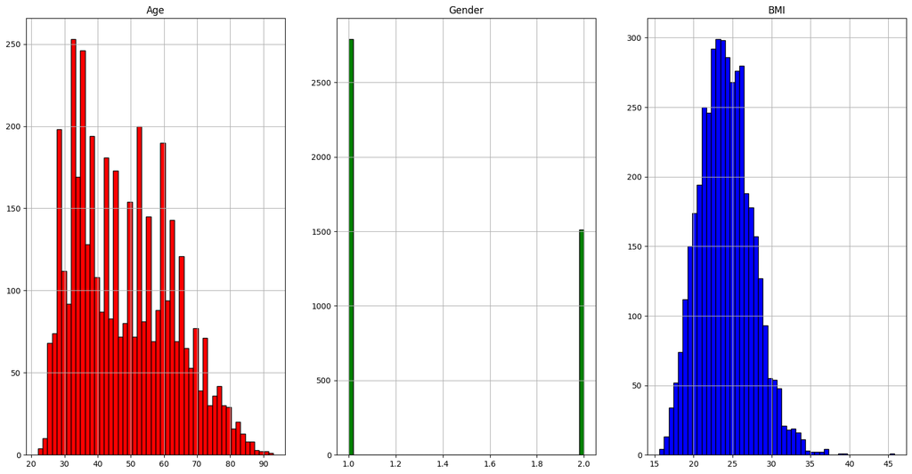

```python
f,ax=plt.subplots(1,3,figsize=(20,10))
df['Age'].hist(ax=ax[0],bins=50, figsize=(20,10),edgecolor='black',color='red')
ax[0].set_title('Age')
df['Gender'].hist(ax=ax[1],bins=50, figsize=(20,10),edgecolor='black',color='green')
ax[1].set_title('Gender')
df['BMI'].hist(ax=ax[2],bins=50, figsize=(20,10),edgecolor='black',color='blue')
ax[2].set_title('BMI')
plt.show()
```

## **9 | Data Visualization using Heatmap**

This command generates a heatmap of the correlation matrix for the dataset's numerical columns, visualizing correlation coefficients and showing relationships between variables.

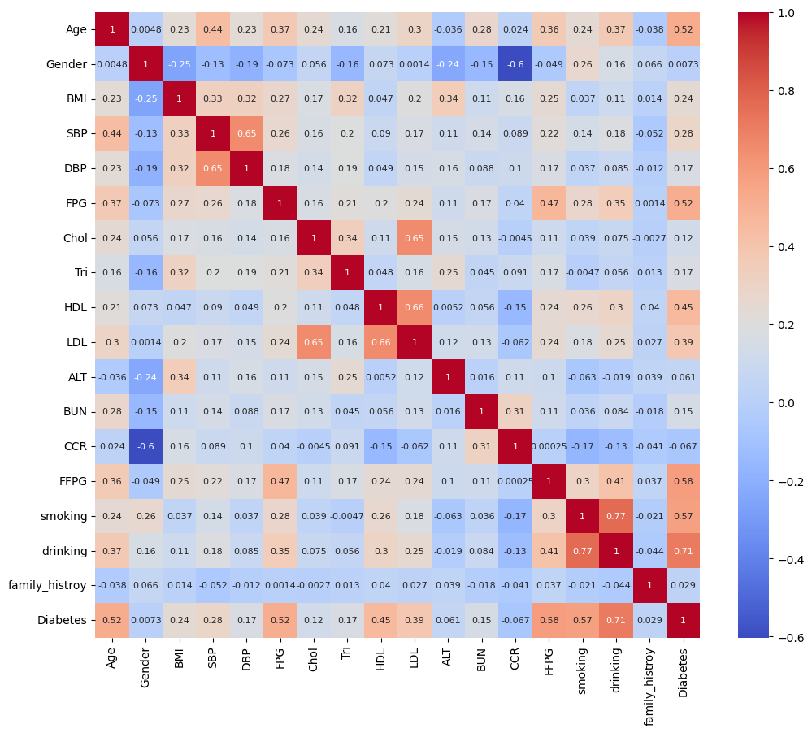

```python
numeric_df = df.select_dtypes(include=[float, int])
corr_matrix = numeric_df.corr()
plt.figure(figsize=(12, 10))
sns.heatmap(corr_matrix, annot=True, cmap='coolwarm', annot_kws={"size": 8})
plt.show()
```

## **10 | Data Visualization using Scatter Plot**

This command creates a scatter plot to display the relationship between the "BMI" and "Chol" columns, with "BMI" on the x-axis and "Chol" on the y-axis.

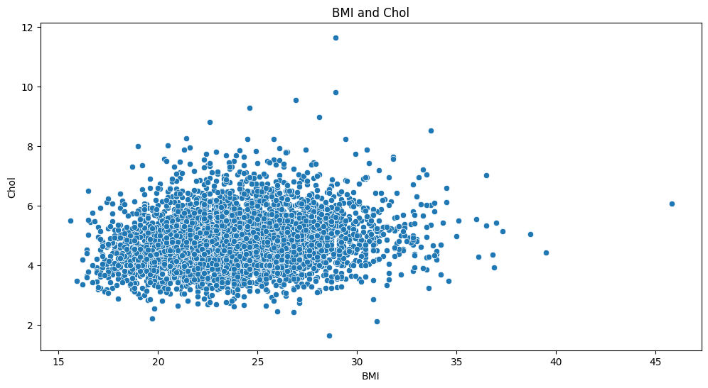

```python
plt.figure(figsize=(12, 6))
sns.scatterplot(data=df, x='BMI', y='Chol')
plt.title('BMI and Chol')
plt.show()
```

## **11 | Data Visualization using Histogram + KDE**

This command creates a histogram with KDE plot to show the "LDL" level distribution for diabetic and non-diabetic patients. Diabetic patients are displayed in red, while non-diabetic patients are shown in blue.

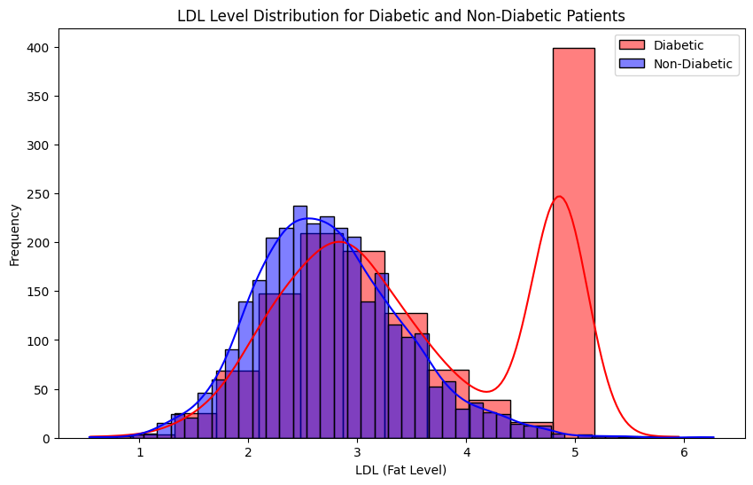

```python
plt.figure(figsize=(10,6))
sns.histplot(df[df['Diabetes'] == 1]['LDL'], color='red', kde=True, label='Diabetic')
sns.histplot(df[df['Diabetes'] == 0]['LDL'], color='blue', kde=True, label='Non-Diabetic')
plt.title('LDL Level Distribution for Diabetic and Non-Diabetic Patients')
plt.xlabel('LDL (Fat Level)')
plt.ylabel('Frequency')
plt.legend()
plt.show()
```